# Are statistics out of control?

Bénédicte Colnet

September 2021

Abstract

This notebook repeats a [blog article](https://scienceetonnante.com/2021/08/30/les-etudes-statistiques-sont-elles-hors-de-controle/) from David Louapre, using the R language. The overall analysis is taken from an article *[Statistically Controlling for Confounding Constructs Is Harder than You Think](https://journals.plos.org/plosone/article?id=10.1371/journal.pone.0152719)* where the quality of a counfounder is shown to have a big impact on the estimand.

# A simple example

Here $z$ is an indicator of life quality, $x$ the champagne consumption (number of glasses per year), and $y$ the life expectancy.

```r
# sample size
N = 300

# indicator of quality of life (salary in euros / month centered on 2000 euros with sd of 500)
z = 2000 + 500 * mvrnorm(n = N, 0, 1)

# Champagne
x = 0 + 0.01*z + 5 * mvrnorm(n = N, 0, 1)

# Life expectancy - imagine a law that is a normal law centered on 75 years and a positive effect of quality of life
y = 75 + 0.005 * z + 2.5 * mvrnorm(n = N, 0, 1)

# observed revenue - basically the true value with noise
z_obs = z + 500 * mvrnorm(n = N, 0, 1)

simulation <- data.frame("Life.quality" = z,
                   "Champagne" = x,
                   "Life.expectancy" = y,
                   "Observed.salary" = z_obs)
```

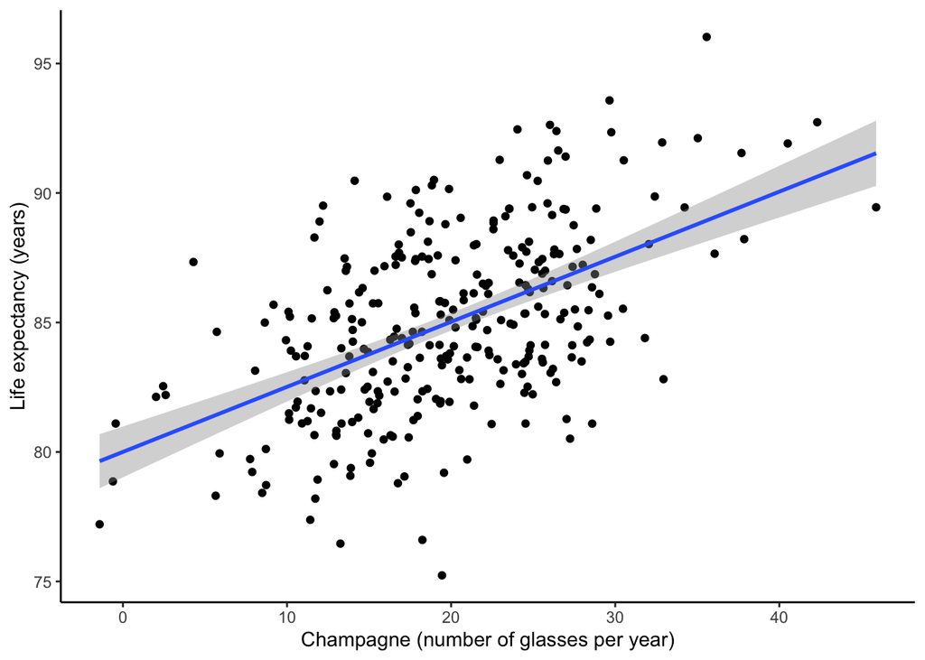

```r
ggplot(simulation, aes(x = Champagne, y = Life.expectancy)) +
  geom_point() +
  theme_classic() +
  geom_smooth(method = 'lm') +
  xlab("Champagne (number of glasses per year)") +
  ylab("Life expectancy (years)")
```

A naive correlation analysis between champagne and the life expectancy gives a significant correlation (very small p-value).

```r
cor.test(simulation$Life.expectancy, simulation$Champagne)
```

```
##
##  Pearson's product-moment correlation
##
## data:  simulation$Life.expectancy and simulation$Champagne
## t = 10.632, df = 298, p-value < 2.2e-16
## alternative hypothesis: true correlation is not equal to 0
## 95 percent confidence interval:
##  0.4371216 0.6019019
## sample estimates:
##       cor
## 0.5244044
```

We can use the $R^2$ to quantify it:

```r
naive.model <- lm(Life.expectancy ~ Champagne, data = simulation)
summary(naive.model)
```

```
##
## Call:
## lm(formula = Life.expectancy ~ Champagne, data = simulation)
##
## Residuals:
##     Min      1Q  Median      3Q     Max
## -9.6515 -2.1942 -0.0762  2.1083  7.0857
##
## Coefficients:
##             Estimate Std. Error t value Pr(>|t|)
## (Intercept) 80.00240    0.49811  160.61   <2e-16 ***
## Champagne    0.25124    0.02363   10.63   <2e-16 ***
## ---
## Signif. codes:  0 '***' 0.001 '**' 0.01 '*' 0.05 '.' 0.1 ' ' 1
##
## Residual standard error: 2.973 on 298 degrees of freedom
## Multiple R-squared:  0.275,  Adjusted R-squared:  0.2726
## F-statistic:   113 on 1 and 298 DF,  p-value: < 2.2e-16
```

> Note that in the article, due to sampling $R^2 = 0.22$ and p-value $= 10^{-17}$, but our values here are very close.

But we have access to a variable that seems to be more plausible to explain the sprurious correlation.

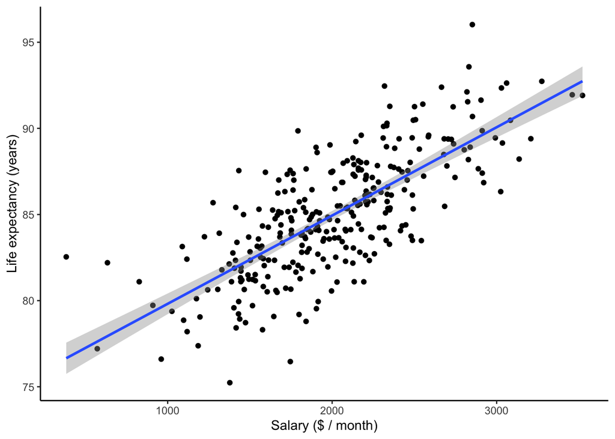

```r
ggplot(simulation, aes(x = Life.quality, y = Life.expectancy)) +
  geom_point() +
  theme_classic() +
  geom_smooth(method = 'lm') +
  xlab("Salary ($ / month)") +
  ylab("Life expectancy (years)")
```

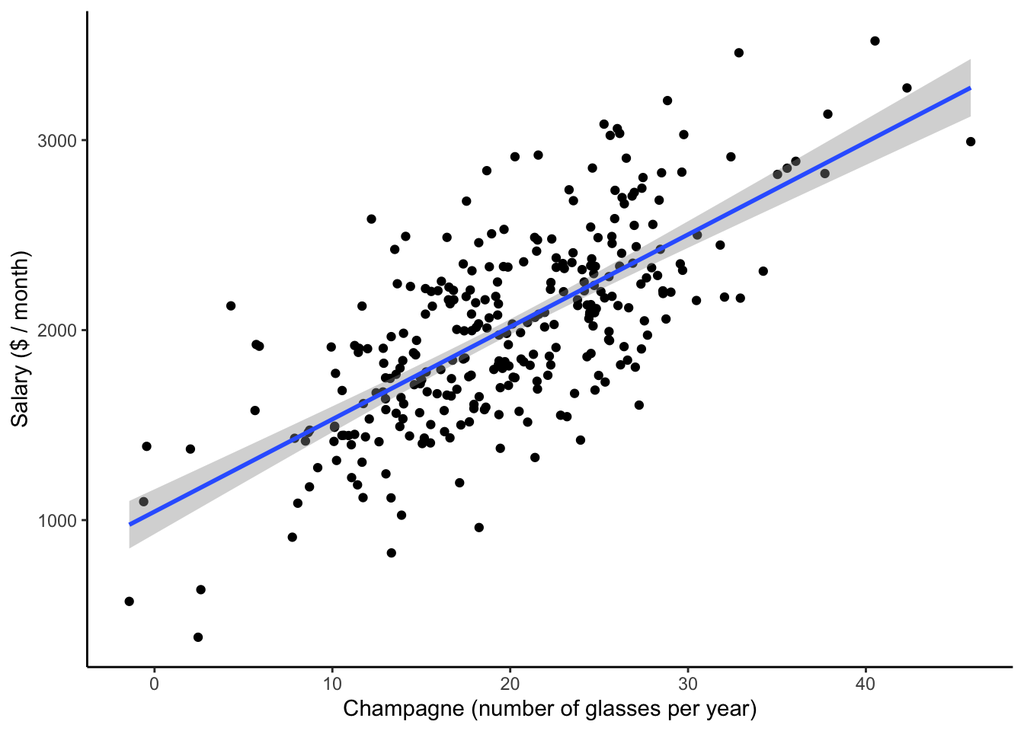

```r
ggplot(simulation, aes(x = Champagne, y = Life.quality)) +
  geom_point() +
  theme_classic() +
  geom_smooth(method = 'lm') +
  xlab("Champagne (number of glasses per year)") +
  ylab("Salary ($ / month)")
```

Using the true life quality variable (i.e salary in our situation), and adjusting the model with it, then the coefficient associated with champagne is no longer significant.

```r
true.model <- lm(Life.expectancy ~ Champagne + Life.quality, data = simulation)
summary(true.model)
```

```
##
## Call:
## lm(formula = Life.expectancy ~ Champagne + Life.quality, data = simulation)
##
## Residuals:
##     Min      1Q  Median      3Q     Max
## -7.1593 -1.5028 -0.0857  1.5948  6.6881
##
## Coefficients:
##               Estimate Std. Error t value Pr(>|t|)
## (Intercept)  7.469e+01  5.623e-01 132.838   <2e-16 ***
## Champagne    4.116e-03  2.642e-02   0.156    0.876
## Life.quality 5.083e-03  3.829e-04  13.276   <2e-16 ***
## ---
## Signif. codes:  0 '***' 0.001 '**' 0.01 '*' 0.05 '.' 0.1 ' ' 1
##
## Residual standard error: 2.359 on 297 degrees of freedom
## Multiple R-squared:  0.545,  Adjusted R-squared:  0.5419
## F-statistic: 177.9 on 2 and 297 DF,  p-value: < 2.2e-16
```

Here the p-value for the Champagne coefficient is not significant, because bigger than 0.05. In `R` it is rather easy to read it with the stars.

But what if we use a proxy? Rather than the salary, we have access to an observed salary.

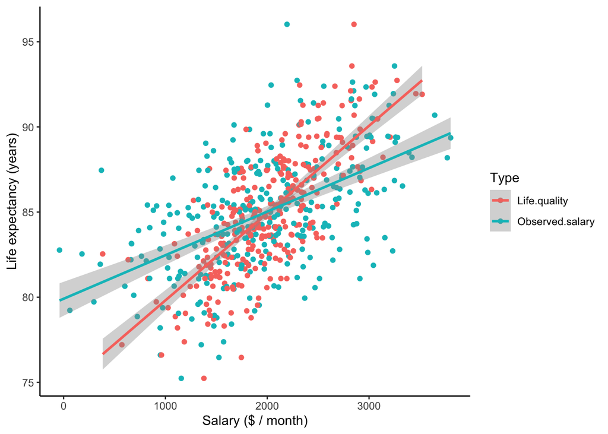

```r
simulation %>%
  pivot_longer(cols = c(Observed.salary, Life.quality), names_to = "Type", values_to = "Salary") %>%
  ggplot(aes(x = Salary, y = Life.expectancy, color = Type, group = Type)) +
  geom_point() +
  theme_classic() +
  geom_smooth(method = 'lm') +
  ylab("Life expectancy (years)") +
  xlab("Salary ($ / month)")
```

```r
proxy.model <- lm(Life.expectancy ~ Champagne + Observed.salary, data = simulation)
summary(proxy.model)
```

```
##
## Call:
## lm(formula = Life.expectancy ~ Champagne + Observed.salary, data = simulation)
##
## Residuals:
##     Min      1Q  Median      3Q     Max
## -8.2805 -1.9251 -0.0548  1.9299  8.0596
##
## Coefficients:
##                  Estimate Std. Error t value Pr(>|t|)
## (Intercept)     7.832e+01  5.343e-01 146.586  < 2e-16 ***
## Champagne       1.665e-01  2.571e-02   6.475 3.91e-10 ***
## Observed.salary 1.698e-03  2.616e-04   6.490 3.59e-10 ***
## ---
## Signif. codes:  0 '***' 0.001 '**' 0.01 '*' 0.05 '.' 0.1 ' ' 1
##
## Residual standard error: 2.787 on 297 degrees of freedom
## Multiple R-squared:  0.3651, Adjusted R-squared:  0.3608
## F-statistic: 85.38 on 2 and 297 DF,  p-value: < 2.2e-16
```

The coefficient before champagne is significant… This is a statistical artefact, due to the fact that adjustment was made with a proxy rather than the true life quality.

An intuitive way to understand why, is that the true variable is not well approximated by the proxy, so that the “remaining part” is somehow captured by the Champagne covariate.

The conclusion is that - as soon as the proxy covariate is considered as the good one - the Champagne is retained as an explanatory covariate. This is a Type 1 error in statistics.

We can also understand this result in term of residual R2, that is:

```r
regress.on.proxy <- lm(Life.expectancy ~ Observed.salary, data = simulation)
simulation$Life.expect.reduced <- predict(regress.on.proxy)

naive <- lm(Life.expect.reduced ~ Champagne, data = simulation)
summary(naive)
```

```
##
## Call:
## lm(formula = Life.expect.reduced ~ Champagne, data = simulation)
##
## Residuals:
##     Min      1Q  Median      3Q     Max
## -4.0869 -1.0679  0.0081  1.1163  3.8958
##
## Coefficients:
##             Estimate Std. Error t value Pr(>|t|)
## (Intercept) 82.44763    0.26448  311.73   <2e-16 ***
## Champagne    0.12767    0.01255   10.17   <2e-16 ***
## ---
## Signif. codes:  0 '***' 0.001 '**' 0.01 '*' 0.05 '.' 0.1 ' ' 1
##
## Residual standard error: 1.579 on 298 degrees of freedom
## Multiple R-squared:  0.2578, Adjusted R-squared:  0.2553
## F-statistic: 103.5 on 1 and 298 DF,  p-value: < 2.2e-16
```

# Toward simulation

To observe how each parameter has an impact, that is the sample size, the quality of the proxy, and the strength of the confounding, one can perform simulations.

```r
compute_simulation <- function(sigma_xy, sigma_z, N = 300){

  # generate true covariate called z
  z = 2000 + 500 * mvrnorm(n = N, 0, 1)

  # generate champagne like covariate
  x = z + sigma_xy * mvrnorm(n = N, 0, 1)

  # generate the outcome covariate
  y = z + sigma_xy * mvrnorm(n = N, 0, 1)

  # generate the proxy
  z_obs = z + sigma_z * mvrnorm(n = N, 0, 1)

  simulation <- data.frame("z" = z,
                           "x" = x,
                           "y" = y,
                           "z_obs" = z_obs)

  return(simulation)
}
```

To reproduce the simulation of *Science Étonnante*, we regress the outcome $y$ on the spurious link $x$ (the Champagne like covariate), and the proxy covariate $z$, that is:

$$y \sim z_{obs} + x,$$

and the p-value found in front of the coefficient for $x$ is analyzed.

```r
test <- compute_simulation(1, 1)
model.test <- lm(y ~ z_obs + x, data = test)
model.test <- summary(model.test)
pvalue <- model.test$coefficients["x", 4]
pvalue
```

```
## [1] 3.686377e-21
```

Intuitively, if we increase the quality of the proxy, this result should change and become no longer significant. For example we propose to divide $\sigma_z$ by 10.

```r
test <- compute_simulation(1, 0.1)
model.test <- lm(y ~ z_obs + x, data = test)
model.test <- summary(model.test)
pvalue <- model.test$coefficients["x", 4]
pvalue
```

```
## [1] 0.3664411
```

Recall that: - The higher $\sigma_z$, the poorer the proxy; - The higher $\sigma_{xy}$, the lower the confounding.

```r
sigma_z <- c(0.1, 0.2, 0.3, 0.4, 0.5,  0.6, 0.7, 0.8, 0.9, 1, 1.1, 1.2)
sigma_xy <- c(1, 1.1, 1.2, 1.3, 1.4, 1.5, 1.6, 1.7, 1.8, 2)
K = 100

results <- data.frame("sigma_z" = c(),
                      "sigma_xy" = c(),
                      "pvalue" = c(),
                      "coefficient" = c())


for (s_z  in sigma_z){
  for (s_xy in sigma_xy){
    for (i in 1:K){
          test <- compute_simulation(s_xy, s_z)
          model.test <- lm(y ~ z_obs + x, data = test)
          model.test <- summary(model.test)
          pvalue <- model.test$coefficients["x", 4]
          coefficient <- model.test$coefficients["x", 1]

          new_row <- data.frame("sigma_z" = s_z,
                            "sigma_xy" = s_xy,
                            "pvalue" = pvalue,
                            "coefficient" = coefficient)
          results <- rbind(results, new_row)
    }
  }
}
```

```r
results$false_positive <- ifelse(results$pvalue < 0.05, 1, 0)
results_treated <- results%>%
  group_by(sigma_z, sigma_xy) %>%
  summarise(total = n(), count = sum(false_positive))
results_treated$percentage <- round(results_treated$count / 100,2)
```

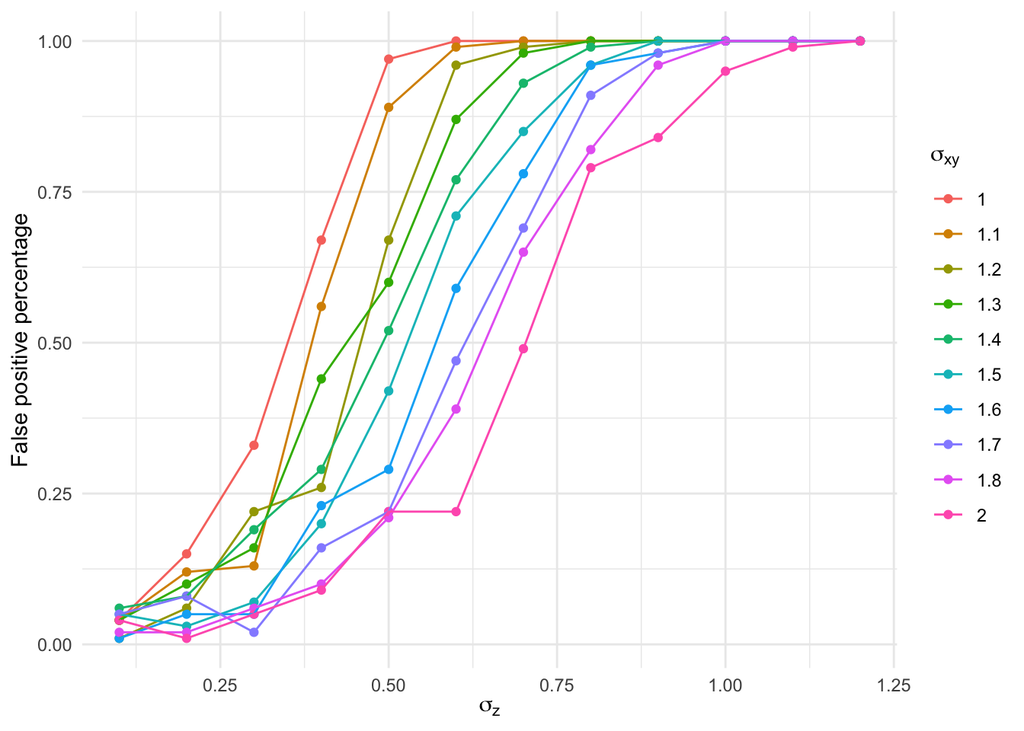

```r
ggplot(results_treated, aes(x = sigma_z, y = percentage, group = as.factor(sigma_xy), color = as.factor(sigma_xy))) +
  geom_point() +
  geom_line() +
  theme_minimal() +
  ylab("False positive percentage") +
  xlab(expression(sigma[z]))  +
  scale_color_discrete(name=expression(sigma[xy]))
```

```r
# ggplot(results_treated, aes(x = sigma_z, y = percentage, group = as.factor(sigma_xy), color = as.factor(sigma_xy))) +
#   geom_smooth(se = FALSE) +
#   theme_minimal() +
#   ylab("False positive percentage") +
#   xlab(expression(sigma[z])) +
#   scale_color_discrete(name=expression(sigma[xy]))
#
```

We could also observe the effect on the champagne coefficient, that is rather looking at if the quantity is significant or not, how strong this coefficient is.

```r
results_coefficient_treated <- results %>%
  group_by(sigma_z, sigma_xy) %>%
  summarise(coefficient = mean(coefficient))
```

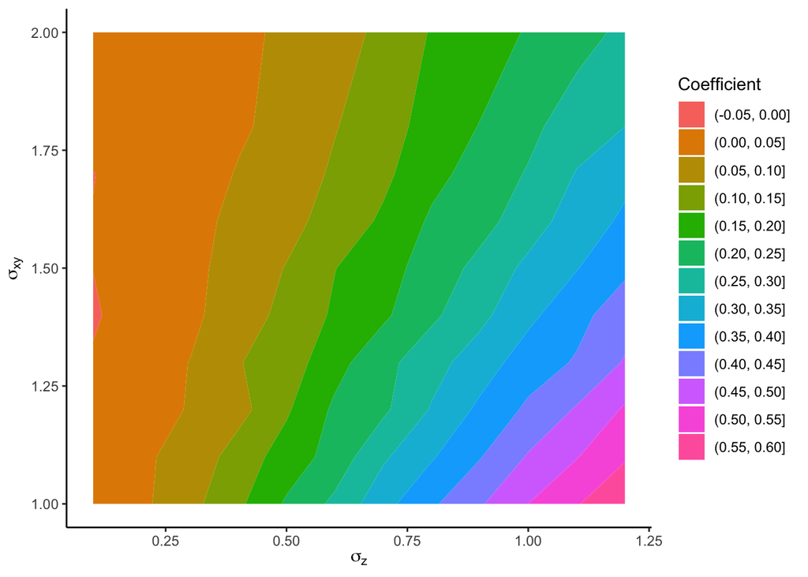

```r
library(ggrepel)

ggplot(results_coefficient_treated, aes(x = sigma_z, y = sigma_xy, z = coefficient)) +
  theme_classic() +
  geom_contour_filled(palette = "Set1") +
  xlab(expression(sigma[z])) +
  ylab(expression(sigma[xy])) +
  scale_fill_discrete(name="Coefficient")
```